# **Data Mining - Pendahuluan NLP-TextMining-TextAnalytics**

[figure not shown]

```python
import warnings, nltk; warnings.simplefilter('ignore')

file_ = 'data/price.csv'
try:
    import google.colab; IN_COLAB = True
    print("Installing the required modules")
    !pip install sastrawi unidecode textblob pyldavis -q
    nltk.download("all")
    !mkdir data
    !wget -P data/ https://raw.githubusercontent.com/taudataanalytics/Data-Mining--Penambangan-Data--Ganjil-2024/master/{file_}
except:
    IN_COLAB = False
    print("Running the code locally, please make sure all the python module versions agree with colab environment and all data/assets downloaded")
```

```
Running the code locally, please make sure all the python module versions agree with colab environment and all data/assets downloaded
```

```python
# Importing Modules untuk Notebook ini
import itertools, re, pickle
import time, numpy as np, matplotlib.pyplot as plt, pandas as pd, seaborn as sns
from matplotlib.colors import ListedColormap
from textblob import TextBlob
from Sastrawi.Stemmer.StemmerFactory import StemmerFactory
from unidecode import unidecode
from nltk.tag import CRFTagger
from html import unescape
from Sastrawi.StopWordRemover.StopWordRemoverFactory import StopWordRemoverFactory
from tqdm import tqdm

factory = StopWordRemoverFactory()
stemmer = StemmerFactory().create_stemmer()
sns.set(style="ticks", color_codes=True)
random_state = 170
'Done'
```

```
'Done'
```

# Detail Materi:

- https://taudata.blogspot.com/2020/04/nlptm-01.html
- https://taudata.blogspot.com/2020/04/nlptm-02.html
- https://taudata.blogspot.com/2022/04/nlptm-03.html
- https://taudata.blogspot.com/2022/04/sma-01.html
- https://taudata.blogspot.com/2022/05/EDA-02C-Text-Visualizations.html

## Text Mining dan NLP?

Natural Language Processing (NLP) - Pemrosesan Bahasa Alami (PBA):

"*Sebuah cabang ilmu (AI/Computational Linguistik) yang mempelajari bagaimana bahasa (alami) manusia (terucap/tertulis) dapat dipahami dengan baik oleh komputer dan komputer dapat merespon dengan cara yang serupa ke manusia*".

[figure not shown]

[**[Image Source]**](https://www.turn-on.de/lifestyle/topliste/zehn-film-gadgets-die-wir-uns-im-wahren-leben-wuenschen-4413)

**Aplikasi Umum NLP:**

1. Machine Translation (Misal https://translate.google.com/ )
2. Information Retrieval (IR) (misal www.google.com, bing, elasticsearch, etc.)
3. Man-Machine Interface (misal Siri, cortana, atau Alexa)

**Apakah Perbedaan antara NLP dan Text Mining (TM)?**

TM (terkadang disebut Text Analytics) adalah sebuah pemrosesan teks (biasanya dalam skala besar) untuk menghasilkan (generate) informasi atau insights. Untuk menghasilkan informasi TM menggunakan beberapa metode, termasuk NLP. TM mengolah teks secara eksplisit, sementara NLP mencoba mencari makna latent (tersembunyi) lewat aturan bahasa (e.g. grammar/idioms/Semantics).  
**Contoh aplikasi TM** : Clustering, Klasifikasi, Social Media Analytics (SMA).

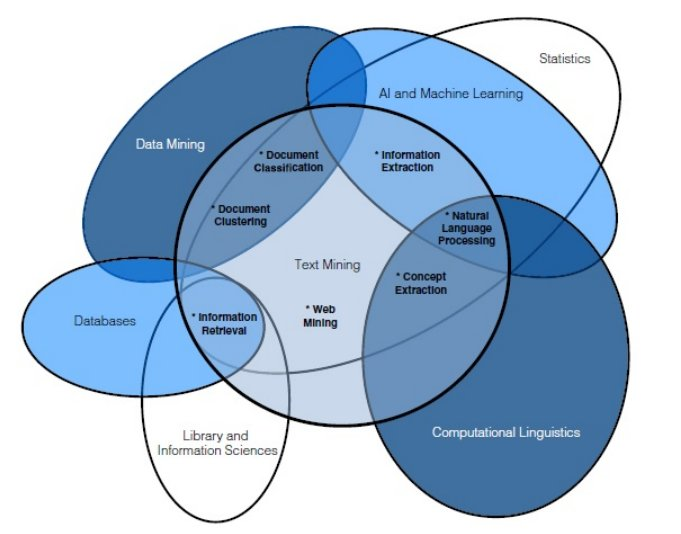

[image source: [Gary M.:"Practical Text Mining and Statistical Analysis for Non-structured Text Data Applications"](https://www.elsevier.com/books/practical-text-mining-and-statistical-analysis-for-non-structured-text-data-applications/miner/978-0-12-386979-1)]

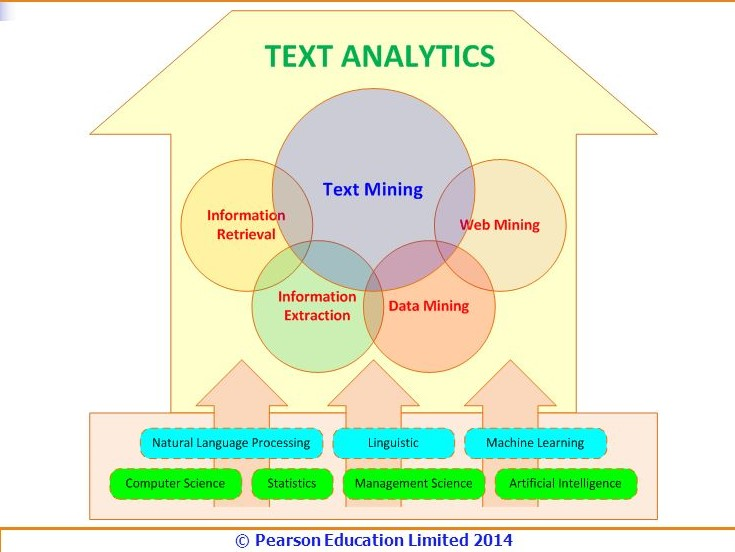

[Image Source: [Efraim T. "Business Intelligence and Analytics: Systems for Decision Support, Global Edition (10e)](http://www.pearson.com.au/products/S-Z-Turban-Sharda/Business-Intelligence-and-Analytics-Systems-for-Decision-Support-Global-Edition/9781292009209?R=9781292009209)"]

## Tokenisasi

Tokenisasi adalah pemisahan kata, simbol, frase, dan entitas penting lainnya (yang disebut sebagai token) dari sebuah teks untuk kemudian di analisa lebih lanjut. Token dalam NLP sering dimaknai dengan "sebuah kata", walau tokenisasi juga bisa dilakukan ke kalimat, paragraf, atau entitas penting lainnya (misal suatu pola string DNA di Bioinformatika).

**Mengapa perlu tokenisasi?**

- Langkah penting dalam preprocessing, menghindari kompleksitas mengolah langsung pada string asal.
- Menghindari masalah (semantic) saat pemrosesan model-model natural language.
- Suatu tahapan sistematis dalam merubah unstructured (text) data ke bentuk terstruktur yang lebih mudah di olah.

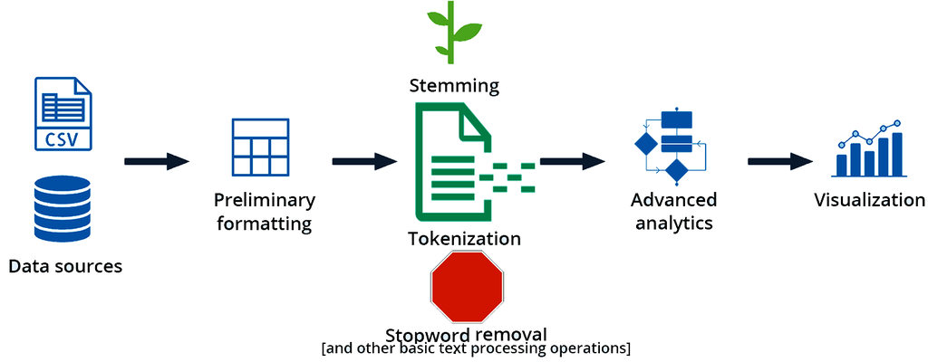

[[**Image Source**](https://www.softwareadvice.com/resources/what-is-text-analytics/)]

## Tokenisasi dengan TextBlob

Kelebihan:

1. Sederhana & mudah untuk digunakan/pelajari.
2. Textblob objects punya behaviour/properties yang sama dengan string di Python.
3. TextBlob dibangun dari kombinasi modul NLTK dan (Clips) Pattern

**Kekurangan**:

1. Tidak secepat Spacy dan NLTK
2. Language Model terbatas: English, German, French

*Blob : Binary large Object

```python
# Tokenizing di TextBlob
T = "Hello, Mr. Man. He smiled!! This, i.e. that, is it :-) ."
print(TextBlob(T).words)
```

```
['Hello', 'Mr', 'Man', 'He', 'smiled', 'This', 'i.e', 'that', 'is', 'it']
```

```python
T.split()
```

```
['Hello,',
 'Mr.',
 'Man.',
 'He',
 'smiled!!',
 'This,',
 'i.e.',
 'that,',
 'is',
 'it',
 ':-)',
 '.']
```

```python
L = TextBlob(T).words
L[3]
```

```
'He'
```

```python
kalimatS = TextBlob(T).sentences
print([str(kalimat) for kalimat in kalimatS])
```

```
['Hello, Mr. Man.', 'He smiled!!', 'This, i.e.', 'that, is it :-) .']
```

```python
# Saat melakukan coding di Python, selalu perhatikan "tipe data" yang dihasilkan oleh modul.
A = TextBlob(T).sentences
B = TextBlob(T).words
print(A[0], type(A[0]))
print(B[0], type(B[0]))
# Apakah bedanya dengan tipe data str biasa di python?
```

```
Hello, Mr. Man. <class 'textblob.blob.Sentence'>
Hello <class 'textblob.blob.Word'>
```

## Tokenisasi tidak hanya language dependent, tapi juga environment dependent

Tokenization sebenarnya tidak sesederhana memisahkan berdasarkan spasi dan removing symbol. Sebagai contoh dalam bahasa Jepang/Cina/Arab suatu kata bisa terdiri dari beberapa karakter.

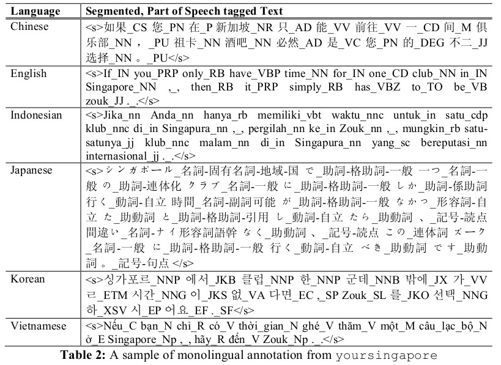

[[**Image Source**](http://aclweb.org/anthology/Y/Y11/Y11-1038.pdf)]

## Tokenisasi (NLP) Bahasa Indonesia:

NLTK belum support Bahasa Indonesia, bahkan module NLP Python yang support bahasa Indonesia secara umum masih sangat langka. Beberapa **resources** yang dapat digunakan:

1. **[KirraLabs](https://github.com/kirralabs/indonesian-NLP-resources)**: Mix of NLP-TextMining resources
2. **[Sastrawi 1.0.1](https://pypi.python.org/pypi/Sastrawi/1.0.1):** untuk "stemming" & **[stopwords](https://devtrik.com/python/stopword-removal-bahasa-indonesia-python-sastrawi/)** bahasa Indonesia.
3. **[Daftar Kata Dasar Indonesia](http://stop-words-list-bahasa-indonesia.blogspot.co.id/2012/09/daftar-kata-dasar-bahasa-indonesia.html)**: Bisa di load sebagai dictionary di Python
4. **[Wiktionary](https://id.wiktionary.org/wiki/Wiktionary:ProyekWiki_bahasa_Indonesia/Daftar_kata)**: ProyekWiki bahasa Indonesia [termasuk Lexicon]
5. [**WordNet Bahasa Indonesia**](http://wn-msa.sourceforge.net/): Bisa di load sebagai dictionary (atau NLTK*) di Python.
6. **[Daftar Kata Baku-Tidak Baku](http://kakakpintar.com/daftar-kata-baku-dan-tidak-baku-a-z-dalam-bahasa-indonesia/)**: Bisa di load sebagai dictionary di Python.
7. **[Spacy](https://spacy.io/)**: Cepat/efisien, MIT License, tapi language model Indonesia masih terbatas.
8. [**UdPipe**](http://ufal.mff.cuni.cz/udpipe): Online request & restricted license (support berbagai bahasa - pemrograman).

**Word Case** (Huruf BESAR/kecil):

- Untuk menganalisa makna (*semantic*) dari suatu (frase) kata dan mencari informasi dalam proses textmining, seringnya (*) kita tidak membutuhkan informasi huruf besar/kecil dari kata tersebut.
- *Text case normaliation* dapat dilakukan pada string secara efisien tanpa melalui tokenisasi (mengapa?).
- Namun, bergantung pada analisa teks yang akan digunakan pengguna harus berhati-hati dengan urutan proses (pipelining) dalam preprocessing. Mengapa dan apa contohnya?

(*) Coba temukan minimal 2 pengecualian dimana huruf kapital/kecil (case) mempengaruhi makna/pemrosesan teks.

```python
# Ignore case (huruf besar/kecil)
T = "Apa Kabar?"
print(T.lower())
print(T.upper())
# Perintah ini sangat efisien karena hanya merubah satu bit di setiap (awal) bytes dari setiap karakter
# Sehingga tetap efisien jika ingin dilakukan sebelum tokenisasi
```

```
apa kabar?
APA KABAR?
```

## Morphological-Linguistic Normalization: Stemming & Lemmatization

(Canonical Representation)

[figure not shown]

## Stemming dan Lemma

1. **Stemmer** akan menghasilkan sebuah bentuk kata yang disepakati oleh suatu sistem tanpa mengindahkan konteks kalimat. Syaratnya beberapa kata dengan makna serupa hanya perlu dipetakan secara konsisten ke sebuah kata baku. Banyak digunakan di IR & komputasinya relatif sedikit. Biasanya dilakukan dengan menghilangkan imbuhan (suffix/prefix).
2. **lemmatisation** akan menghasilkan kata baku (dictionary word) dan bergantung konteks.
3. Lemma & stemming bisa jadi sama-sama menghasilkan suatu akar kata (root word). Misal : *Melompat* ==> *lompat*

**Mengapa melakukan Stemming & Lemmatisasi**?

1. Sering digunakan di IR (Information Retrieval) agar ketika seseorang mencari kata tertentu, maka seluruh kata yang terkait juga diikutsertakan.  
   Misal: *organize*, *organizes*, and *organizing* dan *democracy*, *democratic*, and *democratization*.
2. Di Text Mining Stemming dan Lemmatisasi akan mengurangi dimensi (mengurangi variasi morphologi), yang terkadang akan meningkatkan akurasi.
3. Tapi di IR efeknya malah berkebalikan: **meningkatkan recall, tapi menurunkan akurasi** [[**Link**](https://nlp.stanford.edu/IR-book/html/htmledition/stemming-and-lemmatization-1.html)]. Contoh: kata *operate, operating, operates, operation, operative, operatives, dan operational* jika di stem menjadi *operate*, maka ketika seseorang mencari "*operating system*", maka entry seperti *operational and research* dan *operative and dentistry* akan muncul sebagai entry dengan relevansi yang cukup tinggi.

```python
# Lemmatizer dengan Sastrawi

I = "perayaan itu Berbarengan dengan saat kita bepergian ke Makassar"
print(stemmer.stem(I))
print(stemmer.stem("Perayaan Bepergian Menyuarakan"))
# Ada beberapa hal yang berbeda antara Sastrawi dan modul-modul diatas.
# Apa sajakah?
```

```
raya itu bareng dengan saat kita pergi ke makassar
raya pergi suara
```

## Text Level Normalization: StopWords

Di Text Mining kata-kata yang **sering muncul** (dan jarang sekali muncul) memiliki sedikit sekali informasi (signifikansi) terhadap model (machine learning) yang digunakan. Hal ini di karenakan kata-kata tersebut muncul di semua kategori (di permasalahan klasifikasi) atau di semua cluster (di permasalahan pengelompokan/clustering). Kata-kata yang sering muncul ini biasa disebut "StopWords". Stopwords berbeda-beda bergantung dari Bahasa dan Environment (aplikasi)-nya.  
**Contoh**:

- Stopwords bahasa Inggris: am, is, are, do, the, of, etc.
- Stopwords bahasa Indonesia: adalah, dengan, yang, di, ke, dsb
- Stopwords twitter: RT, ...

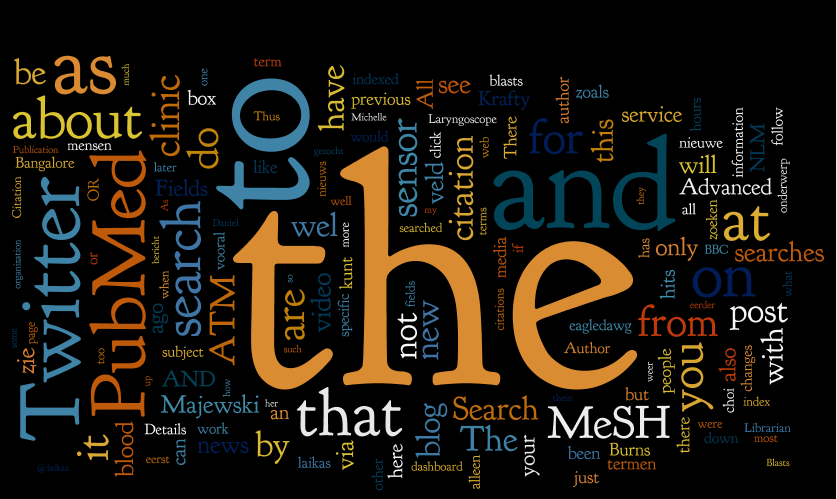

```python
# Loading Stopwords: Ada beberapa cara

Sastrawi_StopWords_id = factory.get_stop_words()

print(Sastrawi_StopWords_id)
print(len(Sastrawi_StopWords_id))

Sastrawi_StopWords_id = set(Sastrawi_StopWords_id) # Biasakan hal ini
```

```
['yang', 'untuk', 'pada', 'ke', 'para', 'namun', 'menurut', 'antara', 'dia', 'dua', 'ia', 'seperti', 'jika', 'jika', 'sehingga', 'kembali', 'dan', 'tidak', 'ini', 'karena', 'kepada', 'oleh', 'saat', 'harus', 'sementara', 'setelah', 'belum', 'kami', 'sekitar', 'bagi', 'serta', 'di', 'dari', 'telah', …
126
```

```python
# Cara menggunakan stopwords

T = "I am doing NLP with tau-data,... adapun saya anu sedang belajar NLP bersama tau-data"
T = T.lower()
Sastrawi_StopWords_id.add('sedang')
Tokens = TextBlob(T).words # Tokenisasi
T2 = [t for t in Tokens if t not in Sastrawi_StopWords_id] # Sastrawi_StopWords_id Personal_StopWords_en Personal_StopWords_id
print(' '.join(T2))
# Catatan: Selalu lakukan Stopword filtering setelah tokenisasi (dan normalisasi).
```

```
i am doing nlp with tau-data adapun belajar nlp bersama tau-data
```

## Menangani Slang atau Singkatan di Data Teks

```python
# Sebuah contoh sederhana
T = 'jangan ragu gan, langsung saja di order pajangannya.'
# Misal kita hendak mengganti setiap singkatan (slang) dengan bentuk penuhnya.
# Dalam hal ini kita hendak mengganti 'gan' dengan 'juragan'
H = T.replace('gan','juragan')
print(H)
# Kita tidak bisa melakukan ini
```

```
janjuragan ragu juragan, langsung saja di order pajanjuragannya.
```

```python
D = {'yg':'yang', 'gan':'juragan'}
D['yg']
```

```
'yang'
```

```python
# dengan tokenisasi
slangS = {'gan':'juragan', 'yg':'yang', 'dgn':'dengan', 'u': 'you', 'ndak':'tidak', 'sesok':'besok', 'gue': 'saya'} #dictionary sederhana berisi daftar singkatan dan kepanjangannya

T = 'jangan ragu gan, langsung saja di order pajangan yg diatas.'
T = TextBlob(T).words
T
```

```
WordList(['jangan', 'ragu', 'gan', 'langsung', 'saja', 'di', 'order', 'pajangan', 'yg', 'diatas'])
```

```python
for i,t in enumerate(T):
    if t in slangS.keys():
        T[i] = slangS[t]
print(' '.join(T))
```

```
jangan ragu juragan langsung saja di order pajangan yang diatas
```

```python
# Test it!
tweet = 'I luv u say. serius gan!, tapi ndak tau kalau sesok.'
T = TextBlob(tweet).words

for i,t in enumerate(T):
    if t in slangS.keys():
        T[i] = slangS[t]

print(' '.join(T))
```

```
I luv you say serius juragan tapi tidak tau kalau besok
```

[figure not shown]

**Beberapa Reguler Expression yang sering digunakan di NLP/Text Mining**

1. Menghilangkan/extract email
2. Menghilangkan/extract nomer telephone
3. Menghilangkan/extract URL di string.
4. Alpha Numeric filtering
5. Wild Card Search
6. Cleaning hashTags di Media Sosial

```python
# Extracting atau replacing eMail.
emailPattern = re.compile(r'[\w._%+-]+@[\w\.-]+\.[a-zA-Z]{2,4}')

txt = 'Contact kami di admin@nlpindonesia.org, nlp.indonesia@sci.yahoo.co.id, atau nlp_nusantara@internet.net'

print( re.sub(emailPattern, ' ', txt) )# clean email
eMailS = re.findall( emailPattern, txt )
print( 'email yang ditemukan: ', str(eMailS) )
```

```
Contact kami di  ,  , atau
email yang ditemukan:  ['admin@nlpindonesia.org', 'nlp.indonesia@sci.yahoo.co.id', 'nlp_nusantara@internet.net']
```

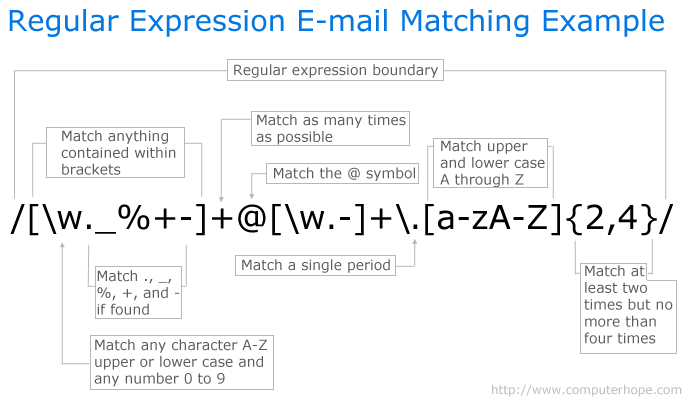

```python
# Pola telephone : \d penanda angka di reguler Expression, \s spasi, dan "|" adalah "atau"
# "?" menyatakan pilihan (optional): colou?r sesuai dengan colour atau color.

phonePattern = re.compile(r'(\d{3}[-\.\s]??\d{3}[-\.\s]??\d{4}|\(\d{3}\)\s*\d{3}[-\.\s]??\d{4}|\d{3}[-\.\s]??\d{4})')
txt = 'Contact kami di 021-7634562 atau 021-763-4562 atau 021 763 4562 atau 0822959020 atau +628199258688'
print(re.sub(phonePattern,' ',txt))# clean phone

noTelp = re.findall(phonePattern,txt)
print('Nomer telephone yang ditemukan: ',str(noTelp))
```

```
Contact kami di   atau   atau   atau   atau + 88
Nomer telephone yang ditemukan:  ['021-7634562', '021-763-4562', '021 763 4562', '0822959020', '6281992586']
```

```python
# Pola telephone 2: untuk setiap angka 8-14 digits dipisahkan oleh "spasi", "," atau "."
phonePattern = re.compile(r'\b\d{8,14}\b')
txt = 'Contact kami di 082295203040 atau +6282295203040'
print(re.sub(phonePattern,'***',txt))# clean phone

noTelp = re.findall(phonePattern,txt)

for no in noTelp:
    if no[0]!='0':
        print('+' + no)
    else:
        print(no)
#print('Nomer telephone yang ditemukan: ',str(noTelp))
```

```
Contact kami di *** atau +***
082295203040
+6282295203040
```

```python
# Website URLS http(s) .... untuk ftp trivial
urlPattern = re.compile(r'http[s]?://(?:[a-zA-Z]|[0-9]|[$-_@.&+]|[!*\(\),]|(?:%[0-9a-fA-F][0-9a-fA-F]))+')

txt = 'website reguler expression & my site : https://www.regular-expressions.info/ & https://tau-data.id'
print(re.sub(urlPattern,' ',txt))# clean urls

URLs = re.findall(urlPattern,txt)# get URLs
print('URL yang ditemukan: ',str(URLs))
```

```
website reguler expression & my site :   &
URL yang ditemukan:  ['https://www.regular-expressions.info/', 'https://tau-data.id']
```

```python
# cleaning non alpha-numeric
txt = 'Hi! @Mukidi, apa kabar? #sapa_Pagi.'
print(re.sub(r'[^\w]',' ',txt))
# atau jika ingin exclude titik dan koma
# re.sub(r'[^.,a-zA-Z0-9 \n\.]','',txt)
```

```
Hi   Mukidi  apa kabar   sapa_Pagi
```

```python
# alternative 2:
print(''.join([t for t in txt if t.isalnum() or t==' ']))
# ada perbedaan?
```

```
Hi Mukidi apa kabar sapaPagi
```

[figure not shown]

```python
# Cleaning hashTags dalam posting media sosial
tweet = 'oh IoT, #AndaiSajaIaTahu #ApaYangAkuRasah... #AlayersTweet #d2d'

getHashtags = re.compile(r"#(\w+)")
print("Tags = {0}".format(re.findall(getHashtags, tweet)))
# temukan hanya tags ... perhatikan IoT bukan Tags walau ada huruf besar & kecil dalam satu kata
```

```
Tags = ['AndaiSajaIaTahu', 'ApaYangAkuRasah', 'AlayersTweet', 'd2d']
```

```python
pisahtags = re.compile(r'[A-Z][^A-Z]*')

for tags in re.findall(getHashtags, tweet):
    print(re.findall(pisahtags, tags))
```

```
['Andai', 'Saja', 'Ia', 'Tahu']
['Apa', 'Yang', 'Aku', 'Rasah']
['Alayers', 'Tweet']
[]
```

```python
# Mengganti hashtags dengan kata dasar pembentuknya
tweet = 'oh IoT, #AndaiSajaIaTahu #ApaYangAkuRasah... #AlayersTweet'
tagS = re.findall(getHashtags, tweet)
for tag in tagS:
    proper_words = ' '.join(re.findall(pisahtags, tag))
    tweet = tweet.replace('#'+tag,proper_words)

print(tweet)
```

```
oh IoT, Andai Saja Ia Tahu Apa Yang Aku Rasah... Alayers Tweet
```

## Encoding-Decoding:

- Hal berikutnya yang perlu diperhatikan dalam memproses data teks adalah encoding-decoding.
- Contoh Encoding: ASCII, utf, latin, dsb.
- saya membahas lebih jauh tetang encoding disini:  
  https://taufiksutanto.blogspot.co.id/2018/01/pereda-sakit-kepala-urgensi-memahami.html
- Berikut adalah sebuah contoh sederhana tantangan proses encoding-decoding ketika kita hendak memproses data yang berasal dari internet atau media sosial.

```python
# kita bisa menggunakan modul unidecode untuk mendapatkan representasi ASCII terdekat
T = "ḊḕḀṙ ₲ØĐ, p̾l̾e̾a̾s̾e ḧḕḶṖ ṁḕ"
print(unidecode(T).lower())
# Bahasa Indonesia dan Inggris secara umum mampu direpresentasikan dalam encoding ASCII:
# https://en.wikipedia.org/wiki/ASCII
```

```
dear god, please help me
```

```python
# Kita juga bisa membersihkan posting media sosial/website dengan entitas html menggunakan fungsi "unescape" di modul "html"

print(unescape('Satu &lt; Tiga&nbsp;&amp; &#169; adalah simbol Copyright'))
```

```
Satu < Tiga & © adalah simbol Copyright
```

# Social Media Analytics (SMA)

### SMA adalah sebuah proses pengumpulan data dari media sosial dan analisanya untuk mendapatkan 'insights' atau informasi berharga untuk suatu tujuan tertentu (definisi diadopsi dari Gartner*).

[figure not shown]

# Crawling/Scrapping Data

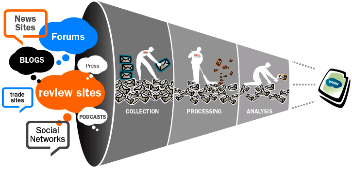

## Read more here: https://taudata.blogspot.com/2022/04/sma-01.html

- Untuk keperluan ini kita akan menggunakan Twint: https://medium.com/@kevctae/twitter-scraping-without-using-twitter-api-2022-guide-39eaec7ccade

```python
# Loading Data
fData = 'data/data-sentimen-indonesia.pckl'
try:
    with open(fData, 'rb') as f:
        data = pickle.load(f)
except:
    data1 = pd.read_csv('https://raw.githubusercontent.com/wiweka24/NLP_Sentiment-Analysis/main/Dataset-Sentimen-Analisis-Bahasa-Indonesia/dataset_komentar_instagram_cyberbullying.csv')
    data2 = pd.read_csv('https://raw.githubusercontent.com/wiweka24/NLP_Sentiment-Analysis/main/Dataset-Sentimen-Analisis-Bahasa-Indonesia/dataset_tweet_sentimen_tayangan_tv.csv')
    data3 = pd.read_csv('https://raw.githubusercontent.com/wiweka24/NLP_Sentiment-Analysis/main/Dataset-Sentimen-Analisis-Bahasa-Indonesia/dataset_tweet_sentiment_cellular_service_provider.csv')
    data4 = pd.read_csv('https://raw.githubusercontent.com/wiweka24/NLP_Sentiment-Analysis/main/Dataset-Sentimen-Analisis-Bahasa-Indonesia/dataset_tweet_sentiment_opini_film.csv')
    data5 = pd.read_csv('https://raw.githubusercontent.com/wiweka24/NLP_Sentiment-Analysis/main/Dataset-Sentimen-Analisis-Bahasa-Indonesia/dataset_tweet_sentiment_pilkada_DKI_2017.csv')
    data1.drop(columns=['Id'], inplace=True)
    data1.rename(columns={'Instagram Comment Text': 'text'}, inplace=True)
    data2.drop(columns=['Id', 'Acara TV', 'Jumlah Retweet'], inplace=True)
    data2.rename(columns={'Text Tweet': 'text'}, inplace=True)
    data3.drop(columns=['Id'], inplace=True)
    data3.rename(columns={'Text Tweet': 'text'}, inplace=True)
    data4.drop(columns=['Id'], inplace=True)
    data4.rename(columns={'Text Tweet': 'text'}, inplace=True)
    data5.drop(columns=['Id', 'Pasangan Calon'], inplace=True)
    data5.rename(columns={'Text Tweet': 'text'}, inplace=True)
    data = pd.concat([data1, data2, data3, data4, data5], ignore_index=True) # Data dijadikan satu
    with open(fData, 'wb') as f:
        pickle.dump(data, f)
data.head()
```

|  | Sentiment | Teks |
| --- | --- | --- |
| 0 | negative | <USERNAME> TOLOL!! Gak ada hubungan nya kegug... |
| 1 | negative | Geblek lo tata...cowo bgt dibela2in balikan...... |
| 2 | negative | Kmrn termewek2 skr lengket lg duhhh kok labil ... |
| 3 | negative | Intinya kalau kesel dengan ATT nya, gausah ke ... |
| 4 | negative | hadewwwww permpuan itu lg!!!!sakit jiwa,knp ha... |

# Kita hanya akan Gunakan isi "Teks" saja

```python
data = data[['Sentiment', 'Teks']]
data.at[0,'Teks']
```

```
" <USERNAME> TOLOL!! Gak ada hubungan nya keguguran dgn pake hijab syar'i yg lo bilang bayi nya kepanasan didalem gak ada hubungan nya woyyyy!! Otak sama jempol lo gak singkron sih ya jadinya asal nulis komentar!"
```

# Pertama-tama kita buat fungsi cleaning text menggunakan topik yang sudah dibahas diatas

```python
def cleanText(txt):
    # Hashtag Preprocessing
    # Singkat/Slang
    docx = unidecode(unescape(txt.lower().strip()))
    urlPattern = re.compile(r'http[s]?://(?:[a-zA-Z]|[0-9]|[$-_@.&+]|[!*\(\),]|(?:%[0-9a-fA-F][0-9a-fA-F]))+')
    docx = re.sub(urlPattern,' ', docx) # Remove links
    docx = re.sub(r'[^\w]', ' ', docx) # Remove Symbol, keep "_" ... recommended
    Tokens = TextBlob(docx).words # Tokenisasi
    docx = ' '.join([t for t in Tokens if str(t) not in Sastrawi_StopWords_id and len(t)>2]) # Stopwords filtering
    docx = stemmer.stem(docx)
    return docx # Silahkan latihan tambahkan penanganan Slang/Singkatan
```

```python
# Test
txt = 'Potret kepedulian personel Polwan RI #MelindungiMelayaniWarga saat menggelar trauma healing untuk anak-anak terdampak gempa bumi yg berada di posko pengungsian di Cianjur, Jawa Barat. Sinergitas Untuk Negeri #Poldajabar.25  https://t.co/fx7C6ShJ8x'
print(txt)
cleanText(txt)
```

```
Potret kepedulian personel Polwan RI #MelindungiMelayaniWarga saat menggelar trauma healing untuk anak-anak terdampak gempa bumi yg berada di posko pengungsian di Cianjur, Jawa Barat. Sinergitas Untuk Negeri #Poldajabar.25  https://t.co/fx7C6ShJ8x
```

```
'potret peduli personel polwan melindungimelayaniwarga gelar trauma healing anak anak dampak gempa bumi ada posko ungsi cianjur jawa barat sinergitas negeri poldajabar'
```

# Aplikasikan ke semua data

```python
# Bisa juga pakai fungsi "apply" ==> lebih cepat
# Sengaja pakai iterrows supaya "prosesnya terlihat"

data['cleaned_text'] = '' # inititate kolom kosong
for idx, post in tqdm(data.iterrows()):
    data.at[idx, 'cleaned_text'] = cleanText(post.Teks)
with open(fData, 'wb') as f:
    pickle.dump(data, f)

data.head()
```

```
2200it [06:25,  5.71it/s]
```

|  | Sentiment | Teks | cleaned_text |
| --- | --- | --- | --- |
| 0 | negative | <USERNAME> TOLOL!! Gak ada hubungan nya kegug... | username tolol gak hubung nya gugur dgn pake h... |
| 1 | negative | Geblek lo tata...cowo bgt dibela2in balikan...... | geblek tata cowo bgt dibela2in balik hadeww nt... |
| 2 | negative | Kmrn termewek2 skr lengket lg duhhh kok labil ... | kmrn termewek2 skr lengket duhhh kok labil bgt... |
| 3 | negative | Intinya kalau kesel dengan ATT nya, gausah ke ... | inti kalau kesel att nya gausah anak kasi buat... |
| 4 | negative | hadewwwww permpuan itu lg!!!!sakit jiwa,knp ha... | hadewwwww permpuan sakit jiwa knp peran utama ... |

```python
cleanText(post.Teks)
```

[output not shown]

# Save hasil text yang sudah dibersihkan ke file Text

```python
# kalau mau bisa di save ke Folder lain yang lebih mudah ditemukan.
data[['cleaned_text']].to_csv("cleaned_text.txt", index=False, encoding='utf8', header=False)
"Done"
```

```
'Done'
```

## Visualisasi ~ Simple Text Analytics

- Tidak seperti data terstruktur, data tidak terstruktur seperti teks termasuk salah satu data yang cukup sulit untuk divisualisasikan.

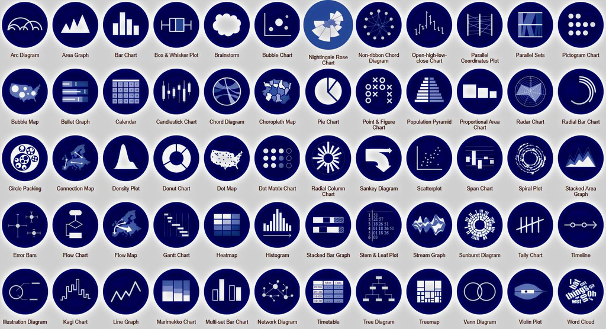

- Namun terdapat Tools seperti Voyant yang dapat membantu dalam visualisasi sekaligus analisis.

[figure not shown]

- https://voyant-tools.org/

### Penggunaan Voyant 1: WordClouds

1. Upload teks yang akan di analisa: hasil cluster/ suatu kategori/ topics / raw text.
2. slider terms: mengkontrol banyaknya terms yang disertakan.
3. **Summary** (statistics)
4. **Documents** ==> add more
5. **Phrases** (n-grams like)
6. **Export** Visualisasi (kanan atas - pertama)
7. **Options** (kanan atas ke-3): Font, size, stopwords, whitelist
8. "?" ==> More Help

### Penggunaan Voyant 2: Bubbles

1. Upload teks yang akan di analisa: hasil cluster/ suatu kategori/ topics / raw text.  
   Atau file yang sudah terupload sebelumnya
2. Klik tanda 4-kotak kecil (kanan atas ke-3)
3. Pilih Visualization Tools ==> Bubbles
4. Option: hanya stopwords
5. Export: Hanya PNG

### Penggunaan Voyant 3: Word Tree

1. Upload teks yang akan di analisa: hasil cluster/ suatu kategori/ topics / raw text.  
   Atau file yang sudah terupload sebelumnya
2. Klik branch untuk expand

### Penggunaan Voyant 4: Links

1. Upload teks yang akan di analisa: hasil cluster/ suatu kategori/ topics / raw text.  
   Atau file yang sudah terupload sebelumnya
2. Visualization Tools ==> Links
3. Klik sembarang terms untuk expand

### Penggunaan Voyant 5: Trends

1. Upload teks yang akan di analisa: hasil cluster/ suatu kategori/ topics / raw text.  
   Atau file yang sudah terupload sebelumnya
2. Document Tools ==> Trends
3. .. Butuh preprocessing ...
4. Data harus terurut waktu
5. Berikut contohnya

```python
# Importing Modules untuk Notebook ini
import warnings; warnings.simplefilter('ignore')
import itertools, re, nltk
import time, numpy as np, matplotlib.pyplot as plt, pandas as pd, seaborn as sns
from matplotlib.colors import ListedColormap
from textblob import TextBlob
from Sastrawi.Stemmer.StemmerFactory import StemmerFactory
from unidecode import unidecode
from nltk.tag import CRFTagger
from html import unescape
from Sastrawi.StopWordRemover.StopWordRemoverFactory import StopWordRemoverFactory
from tqdm import tqdm

factory = StopWordRemoverFactory()
stemmer = StemmerFactory().create_stemmer()
sns.set(style="ticks", color_codes=True)
random_state = 170
'Done'
```

```
'Done'
```

# Detail Materi:

- https://taudata.blogspot.com/2022/04/nlptm-05.html
- https://taudata.blogspot.com/2022/05/nlptm-07.html
- https://taudata.blogspot.com/2022/05/nlptm-06.html

**Contoh bentuk umum representasi dokumen:**

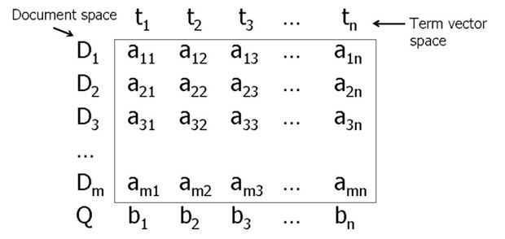

Pada Model *n-grams* kolom bisa juga berupa frase.

## Custom tf-idf:

- Menurut http://scikit-learn.org/stable/modules/generated/sklearn.feature_extraction.text.TfidfVectorizer.html
- default formula tf-idf yang digunakan sk-learn adalah:
- $tfidf = tf * log(\frac{N}{df+1})$ ==> Smooth IDF
- namun kita merubahnya menjadi:
- $tfidf = tf * log(\frac{N}{df})$ ==> Non Smooth IDF
- $tfidf = tf * log(\frac{N}{df+1})$ ==> linear_tf, Smooth IDF
- $tfidf = (1+log(tf)) * log(\frac{N}{df})$ ==> sublinear_tf, Non Smooth IDF

```python
from sklearn.feature_extraction.text import CountVectorizer

d1 = '@udin76, Minum kopi pagi-pagi sambil makan pisang goreng is the best'
d2 = 'Belajar NLP dan Text Mining ternyata seru banget sadiezz'
d3 =  'Sudah lumayan lama bingits tukang Bakso belum lewat'
d4 = 'Aduh ga banget makan Mie Ayam p4k4i kesyap, please deh'

D = [d1, d2, d3, d4]
# Jika kita menggunakan cara biasa:
vectorizer = CountVectorizer(binary = False, lowercase=True)
vsm = vectorizer.fit_transform(D)
print(type(vsm))
print(vectorizer.vocabulary_)
```

```
<class 'scipy.sparse._csr.csr_matrix'>
{'udin76': 35, 'minum': 21, 'kopi': 14, 'pagi': 24, 'sambil': 28, 'makan': 18, 'pisang': 25, 'goreng': 11, 'is': 12, 'the': 33, 'best': 6, 'belajar': 4, 'nlp': 22, 'dan': 8, 'text': 32, 'mining': 20, 'ternyata': 31, 'seru': 29, 'banget': 3, 'sadiezz': 27, 'sudah': 30, 'lumayan': 17, 'lama': 15, 'bin…
```

```python
# Mengakses Datanya [dokumen pertama]
print(vsm[0].data)
print(vsm[0].indices)
```

```
[1 1 1 2 1 1 1 1 1 1 1]
[35 21 14 24 28 18 25 11 12 33  6]
```

```python
vsm.toarray()
```

```
array([[0, 0, 0, 0, 0, 0, 1, 0, 0, 0, 0, 1, 1, 0, 1, 0, 0, 0, 1, 0, 0, 1,
        0, 0, 2, 1, 0, 0, 1, 0, 0, 0, 0, 1, 0, 1],
       [0, 0, 0, 1, 1, 0, 0, 0, 1, 0, 0, 0, 0, 0, 0, 0, 0, 0, 0, 0, 1, 0,
        1, 0, 0, 0, 0, 1, 0, 1, 0, 1, 1, 0, 0, 0],
       [0, 0, 1, 0, 0, 1, 0, 1, 0, 0, 0, 0, 0, 0, 0, 1, 1, 1, 0, 0, 0, 0,
        0, 0, 0, 0, 0, 0, 0, 0, 1, 0, 0, 0, 1, 0],
       [1, 1, 0, 1, 0, 0, 0, 0, 0, 1, 1, 0, 0, 1, 0, 0, 0, 0, 1, 1, 0, 0,
        0, 1, 0, 0, 1, 0, 0, 0, 0, 0, 0, 0, 0, 0]], dtype=int64)
```

# Soft Clustering/Topic Modelling

### Namun kenyataannya seperti ini:

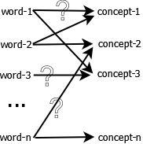

misal kemarin "book", "bank", dsb

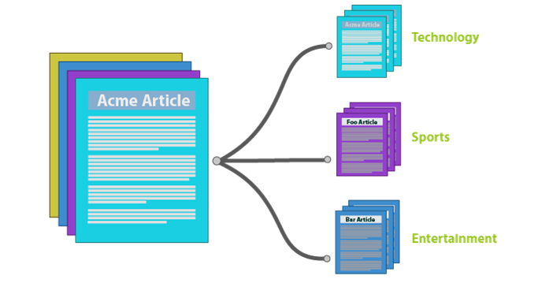

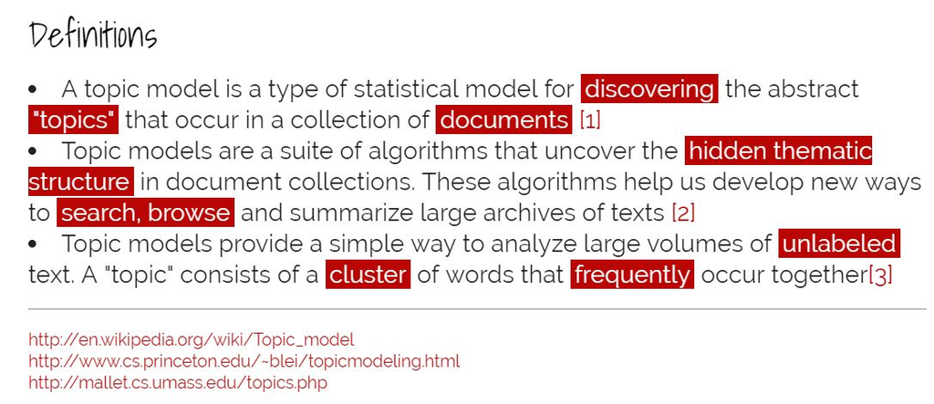

## Latent Dirichlet Allocation

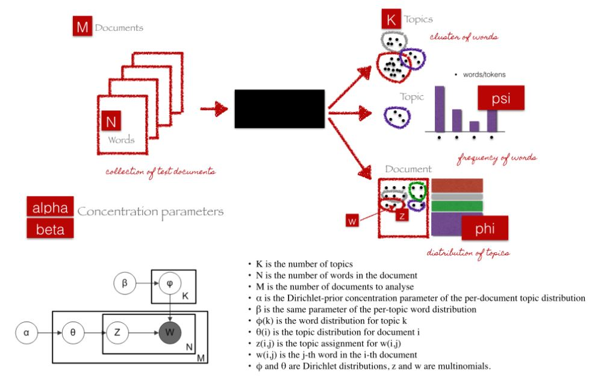

- Penjelasan intuitif yang baik: https://medium.com/@lettier/how-does-lda-work-ill-explain-using-emoji-108abf40fa7d
- inconjunction dengan interactive program berikut: https://lettier.com/projects/lda-topic-modeling/

```python
data.head()
```

|  | Sentiment | Teks | cleaned_text |
| --- | --- | --- | --- |
| 0 | negative | <USERNAME> TOLOL!! Gak ada hubungan nya kegug... | username tolol gak hubung nya gugur dgn pake h... |
| 1 | negative | Geblek lo tata...cowo bgt dibela2in balikan...... | geblek tata cowo bgt dibela2in balik hadeww nt... |
| 2 | negative | Kmrn termewek2 skr lengket lg duhhh kok labil ... | kmrn termewek2 skr lengket duhhh kok labil bgt... |
| 3 | negative | Intinya kalau kesel dengan ATT nya, gausah ke ... | inti kalau kesel att nya gausah anak kasi buat... |
| 4 | negative | hadewwwww permpuan itu lg!!!!sakit jiwa,knp ha... | hadewwwww permpuan sakit jiwa knp peran utama ... |

# Topic Modelling adalah metode Unsupervised Learning (Data Exploratory Model), sehingga kita tidak perlu membagi menjadi training dan test data.

```python
data.head()
```

|  | Sentiment | Teks | cleaned_text |
| --- | --- | --- | --- |
| 0 | negative | <USERNAME> TOLOL!! Gak ada hubungan nya kegug... | username tolol gak hubung nya gugur dgn pake h... |
| 1 | negative | Geblek lo tata...cowo bgt dibela2in balikan...... | geblek tata cowo bgt dibela2in balik hadeww nt... |
| 2 | negative | Kmrn termewek2 skr lengket lg duhhh kok labil ... | kmrn termewek2 skr lengket duhhh kok labil bgt... |
| 3 | negative | Intinya kalau kesel dengan ATT nya, gausah ke ... | inti kalau kesel att nya gausah anak kasi buat... |
| 4 | negative | hadewwwww permpuan itu lg!!!!sakit jiwa,knp ha... | hadewwwww permpuan sakit jiwa knp peran utama ... |

```python
vectorizer = CountVectorizer(binary = False, lowercase=True)
vsm = vectorizer.fit_transform(data['cleaned_text'])
# Mengapa tf bukan tfidf?
# Blei, D. M., Ng, A. Y., & Jordan, M. I. (2003). Latent dirichlet allocation. Journal of machine Learning research, 3(Jan), 993-1022.
# Saran: untuk penelitian VS di Industri.
print(vsm.shape) # Sama
```

```
(2200, 5826)
```

```python
# Dilanjutkan dengan membentuk model LDA-nya
from sklearn.decomposition import LatentDirichletAllocation as LDA
# https://scikit-learn.org/stable/modules/generated/sklearn.decomposition.LatentDirichletAllocation.html
n_topics = 2
lda = LDA(n_components=n_topics, learning_method='batch', random_state=0).fit(vsm)
lda
```

```
LatentDirichletAllocation(n_components=2, random_state=0)
```

```python
# Melihat Topik-topiknya
vsm_topics = lda.transform(vsm)
print(vsm_topics.shape)
vsm_topics[:10]
# Ukuran kolom = #Topics ==> Dimension Reduction
```

```
(2200, 2)
```

```
array([[0.01860881, 0.98139119],
       [0.78387174, 0.21612826],
       [0.77395408, 0.22604592],
       [0.01392774, 0.98607226],
       [0.03581082, 0.96418918],
       [0.02199043, 0.97800957],
       [0.00918029, 0.99081971],
       [0.65896265, 0.34103735],
       [0.0575326 , 0.9424674 ],
       [0.92268529, 0.07731471]])
```

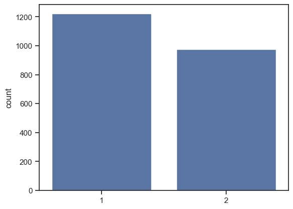

```python
# Seandainya diasumsikan 1 dokumen hanya 1 topic dengan nilai skor topic terbesar
doc_topic =  [a.argmax()+1 for a in tqdm(vsm_topics)] # topic of docs
p = sns.countplot(x=doc_topic)
```

```python
import pyLDAvis, pyLDAvis.lda_model; pyLDAvis.enable_notebook()

pyLDAvis.lda_model.prepare(lda, vsm, vectorizer)
```

[interactive chart not shown]

# Sentimen Analysis

- Sentiment analysis, also called opinion mining, is the field of study that analyzes people’s opinions, sentiments, appraisals, attitudes, and emotions toward entities and their attributes expressed in written text [Bing Liu 2014].

**Contoh aplikasi Sentiment Analysis**

- **Business**: tanggapan konsumen atas suatu produk.
- **Politics**: Sentimen masyarakat sebagai strategi pemenangan pemilu/pilkada.

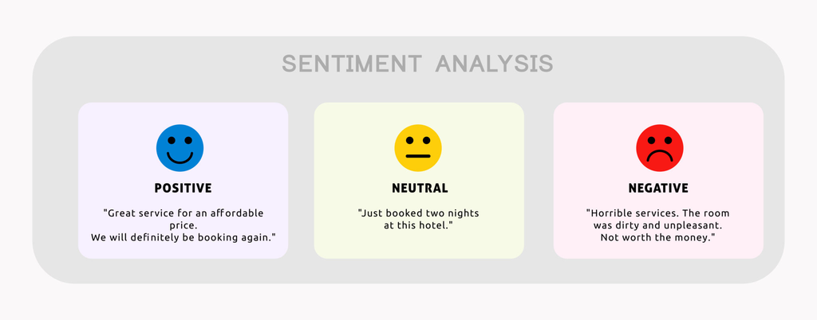

```python
from textblob import TextBlob
# Lexicon Based berdasarkan
# pattern = https://www.clips.uantwerpen.be/pages/pattern-en#sentiment
Sentence = "rendang is yummy ... great for lunch"
testimonial = TextBlob(Sentence)
print(testimonial.sentiment)
print('Polarity=Sentimen =', testimonial.sentiment.polarity)
```

```
Sentiment(polarity=0.8, subjectivity=0.75)
Polarity=Sentimen = 0.8
```

# Bagaimana Dengan Bahasa Indonesia?

- A "simple" trick
- Lexicon and Machine Translation based Method:

Bojar, O., & Veselovská, K. (2015). Resources for Indonesian Sentiment Analysis. The Prague Bulletin of Mathematical Linguistics, 103(1), 21-41.

- https://ufal.mff.cuni.cz/pbml/103/art-franky-bojar-veselovska.pdf?fbclid=IwAR3_Ojz2oF_ezH7IHb6iqMxN3ouIIBlDDyC6QBEO7455niVDQvzfbIjKlm0

# Better Unsupervised Sentiment Analysis

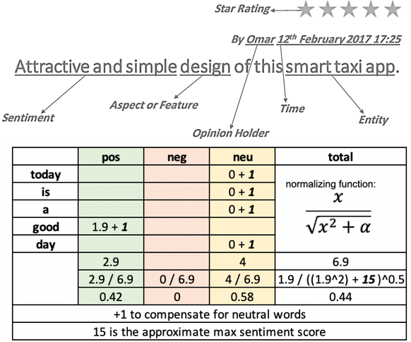

- Feature Engineering, Lexicon Based, & Bayesian Model
- image source:
- http://pasaentuciudad.com.mx/sentiment-analysis%E2%80%8A-%E2%80%8Acomparing-3-common-approaches-naive-bayes-lstm-and-vader/
- https://www.emerald.com/insight/content/doi/10.1016/j.aci.2019.11.003/full/html

# Improvement Implementasi di Industri

- **Hierarchical Classification**: Aspect-Based Sentiment Analysis
- **Hybrid Model**: Sentimen Analysis ==> Topic Modelling

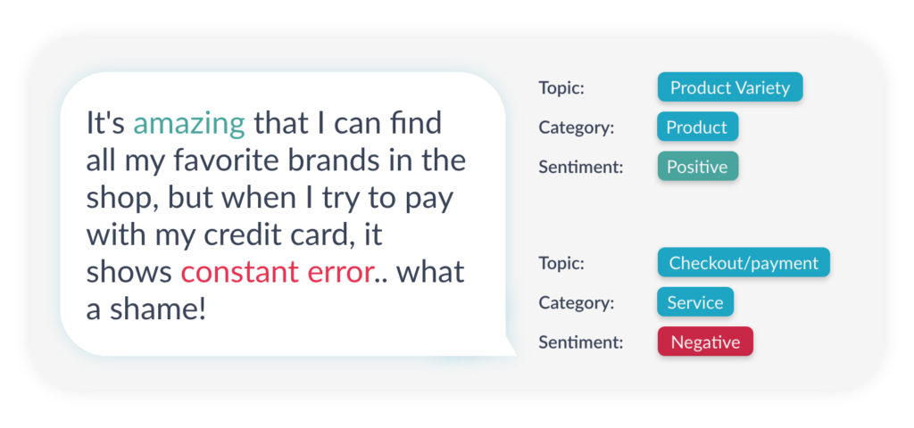